# Задание 2

К вам поступила информация о числе заказов за прошедшие 3 месяца с разрешением по неделям. Постройте (если это возможно) прогноз продаж на следующие 3 месяца, с учётом того, что в неделю с 2020-02-02 по 2020-02-09 была проведена массивная акция, повысившая число заказов на 7%

| Дата | Число заказов |
| --- | --- |
| 2020-01-05 | 650 |
| 2020-01-12 | 837 |
| 2020-01-19 | 1020 |
| 2020-01-26 | 1176 |
| ... | ... |

Данные продублированы в [файле](https://stepik.org/media/attachments/lesson/426638/test2_completed.csv)

```python
import pandas as pd
import numpy as np

from fbprophet import Prophet
from fbprophet.plot import plot_plotly, plot_components_plotly
import holidays

import matplotlib.pyplot as plt
import seaborn as sns
import plotly.express as px
import plotly.graph_objects as go
from plotly.offline import iplot

from sklearn.linear_model import LinearRegression
```

```python
data = pd.read_csv('test2_completed.csv')

print(data.shape)

data.columns = ['ds', 'y']
data.ds = pd.to_datetime(data.ds)
data
```

```
(14, 2)
```

|  | ds | y |
| --- | --- | --- |
| 0 | 2020-01-05 | 650 |
| 1 | 2020-01-12 | 837 |
| 2 | 2020-01-19 | 1020 |
| 3 | 2020-01-26 | 1176 |
| 4 | 2020-02-02 | 1489 |
| 5 | 2020-02-09 | 1823 |
| 6 | 2020-02-16 | 1991 |
| 7 | 2020-02-23 | 2166 |
| 8 | 2020-03-01 | 2334 |
| 9 | 2020-03-08 | 2607 |
| 10 | 2020-03-15 | 2734 |
| 11 | 2020-03-22 | 3492 |
| 12 | 2020-03-29 | 3608 |
| 13 | 2020-04-05 | 3857 |

Посмотрим на исходные данные на графике.

Ничего не сказано о продажах какого продукта идет речь. Если данные реальные, то скорее всего это какой-то новый продукт или сервис, который запустили или начали продавать в конце 2019 года.

Видно, что тренд роста продаж линейный и все время растет. Сразу можно отметить, что данных мало (3 месяца) и этот период равен периоду, за который нам требуется предсказать продажи. Из-за этого мы не сможем учесть сезонность, может быть получится учесть только влияние праздников и выходных. Кроме того количество продаж не может быть бесконечным и следовало бы учитывать естественную "емкость" системы и строить тренд с насыщением.

Еще стоит отметить резкий рост продаж в середине марта 2020 года. Возможно, повысился спрос из-за эпидемии COVID. Скорее всего это аномалия и модель ее не сможет учесть.

Как попробуем предсказать продажи?

В качестве бейзлайна можно рассмотреть линейную регрессию. Потом попробовать библиотеку Facebook Prophet.

Материалы и идеи взяты из статьи на [Хабре](https://habr.com/ru/company/ods/blog/323730/) и [вебинара](https://youtu.be/JQXCHE0H46U).

```python
iplot([
    go.Scatter(x=data['ds'], y=data['y'], name='y')
])
```

[interactive chart not shown]

Для оценки качества прогноза уберем из обучения несколько последних недель.

Сравнивать прогнозы будем по метрикам MAPE (mean absolute percentage error) и MAE (mean absolute error).

```python
prediction_weeks = 6

train_df = data[:-prediction_weeks]
test_df = data[-prediction_weeks:]
```

**Линейная регрессия**

```python
X_train = train_df.index.values[:, np.newaxis]
y_train = train_df['y'].values[:, np.newaxis]
X_test = test_df.index.values[:, np.newaxis]
y_test = test_df['y'].values[:, np.newaxis]
```

```python
model = LinearRegression()
model.fit(X_train, y_train)
yhat = model.predict(X_test)
```

```python
def get_metrics_lr(y, yhat):
    error = y - yhat
    percent = 100*error/y

    mae = np.mean(abs(error))
    mape = np.mean(abs(percent))

    print("Linear regression:")
    print("MAE: {:.2f}".format(mae))
    print("MAPE: {:.2f}%".format(mape))
```

```python
get_metrics_lr(y_test, yhat)
```

```
Linear regression:
MAE: 205.86
MAPE: 6.16%
```

**Facebook Facebook Prophet**

```python
def plot_forecast(df, forecast, split_date):
    fig = go.Figure()

    # train area
    fig.add_vrect(x0=forecast['ds'].min(), x1=split_date,
                     fillcolor="blue", opacity=0.08, layer="below", line_width=0)

    # test area
    fig.add_vrect(x0=split_date, x1=forecast['ds'].max(),
                     fillcolor="red", opacity=0.08, layer="below", line_width=0)

    fig.add_traces([
        go.Scatter(x=df['ds'], y=df['y'], name='fact'),
        go.Scatter(x=forecast['ds'], y=forecast['yhat'], name='yhat'),
        go.Scatter(x=forecast['ds'], y=forecast['yhat_upper'], fill='tonexty', mode='none', name='upper', visible='legendonly'),
        go.Scatter(x=forecast['ds'], y=forecast['yhat_lower'], fill='tonexty', mode='none', name='lower', visible='legendonly'),
        go.Scatter(x=forecast['ds'], y=forecast['trend'], name='trend', visible='legendonly')
    ])

    iplot(fig)
```

```python
def get_metrics_fprophet(data, forecast, predictions):
    cmp_df = forecast.set_index('ds')[['yhat', 'yhat_lower', 'yhat_upper']].join(data.set_index('ds'))
    cmp_df['error'] = cmp_df['y'] - cmp_df['yhat']
    cmp_df['percent'] = 100*cmp_df['error']/cmp_df['y']

    print("Facebook Prophet:")
    print("MAE: {:.2f}".format(np.mean(abs(cmp_df[-predictions:]['error']))))
    print("MAPE: {:.2f}%".format(np.mean(abs(cmp_df[-predictions:]['percent']))))
```

```python
# Учитываем праздники
holidays_ru = holidays.RU(years=(2020))
df_holidays = pd.DataFrame.from_dict(holidays_ru, orient='index').reset_index()
df_holidays = df_holidays.rename({'index':'ds', 0:'holiday'}, axis ='columns')
df_holidays['ds'] = pd.to_datetime(df_holidays.ds)
df_holidays = df_holidays.sort_values(by=['ds'])
df_holidays.head(3)
```

|  | ds | holiday |
| --- | --- | --- |
| 0 | 2020-01-01 | Новый год |
| 1 | 2020-01-02 | Новый год |
| 2 | 2020-01-03 | Новый год |

```python
model = Prophet(holidays=df_holidays,
                daily_seasonality=False,
                weekly_seasonality=False,
                yearly_seasonality=False,
                changepoints=['2020-02-09'])

model.fit(train_df)

future = model.make_future_dataframe(periods=prediction_weeks, freq='W')
forecast = model.predict(future)
```

```python
get_metrics_fprophet(data, forecast, prediction_weeks)
```

```
Facebook Prophet:
MAE: 183.07
MAPE: 5.99%
```

```python
plot_forecast(data, forecast, split_date=train_df['ds'].max())
```

[interactive chart not shown]

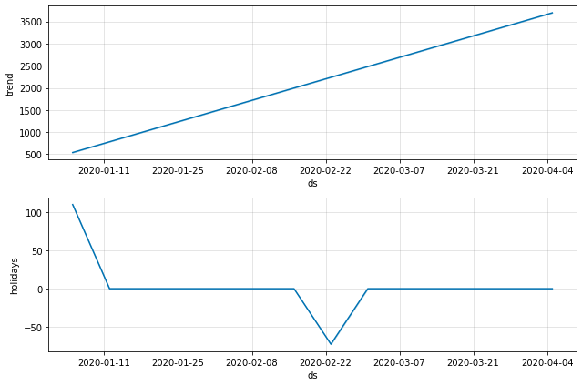

```python
model.plot_components(forecast);
```

В результате мы получили, что при самом базовом решении модель ошибается на 6.16%, при использовании модели сложнее ошибка немного меньше - 5.99%. Эта ошибка в абсолютных величинах составляет примерно 183 продажи в среднем. На мой взгляд, это достаточно много для только что запущенного бизнеса/продукта/сервиса.

Что могло улучшить прогноз?

- большее количество наблюдений
- внимательное изучение аномалии в марте с учетом особенностей бизнеса

Обучение на всех имеющихся данных и прогноз продаж:

```python
model = Prophet(holidays=df_holidays,
                daily_seasonality=False,
                weekly_seasonality=False,
                yearly_seasonality=False,\
                changepoints=['2020-02-09'])

model.fit(data)

future = model.make_future_dataframe(periods=13, freq='W')
forecast = model.predict(future)
```

```python
plot_forecast(data, forecast, split_date=data['ds'].max())
```

[interactive chart not shown]